# Настройка списков управления доступом (ACL)

Лабораторная работа №10

Гафоров Нурмухаммад

Российский университет дружбы народов, Москва, Россия

12.04.2026

# Цель работы

## Цель

Освоить настройку прав доступа пользователей  
к ресурсам сети с помощью расширенных ACL  
в Cisco Packet Tracer.

# Ход выполнения

## Исходная топология сети

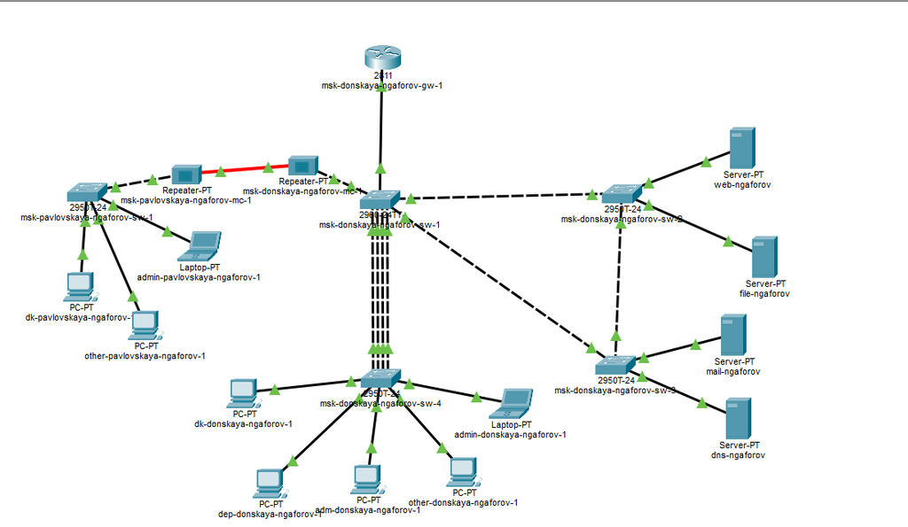

Топология сети

## Подключение ноутбука администратора

- Ноутбук **admin-donskaya-ngaforov-1**
- Подключён к порту **FastEthernet0/24** коммутатора **msk-donskaya-ngaforov-sw-4**

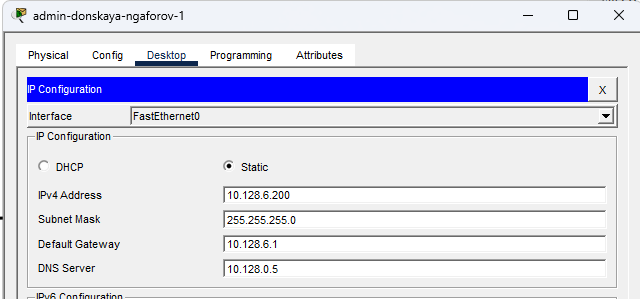

Настройка IP-адреса администратора

## Проверка параметров узла admin

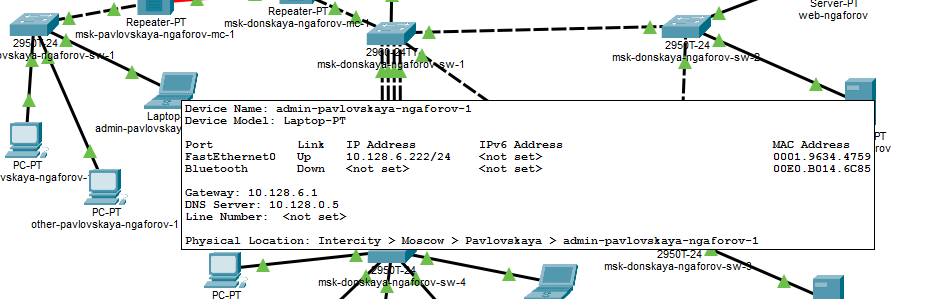

Проверка параметров узла admin

## Настройка ACL для серверной сети

- На маршрутизаторе создан ACL **servers-out**
- Разрешён доступ:
  - ко **web-серверу** по **HTTP**
  - к **mail-серверу** по **SMTP** и **POP3**
  - к **DNS-серверу** по **UDP/53**
  - в сторону серверов по **ICMP**
- Администратору дополнительно открыт доступ по **FTP** и **Telnet**

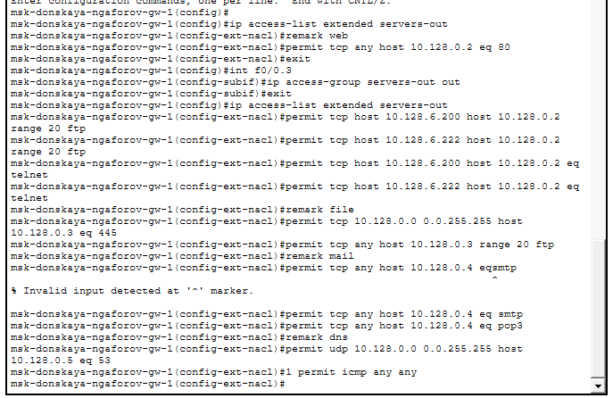

Настройка ACL servers-out

## ACL для сети Other и сети управления

- Создан ACL **other-in**
  - пользователям сети **Other** запрещён выход за пределы своей сети
  - для администратора оставлено разрешение
- Создан ACL **management-out**
  - доступ к сети **10.128.1.0/24** разрешён только администраторам

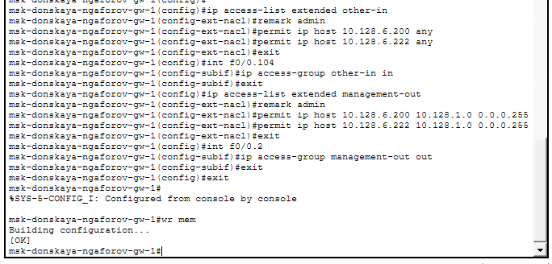

Настройка ACL other-in и management-out

## Проверка созданных списков доступа

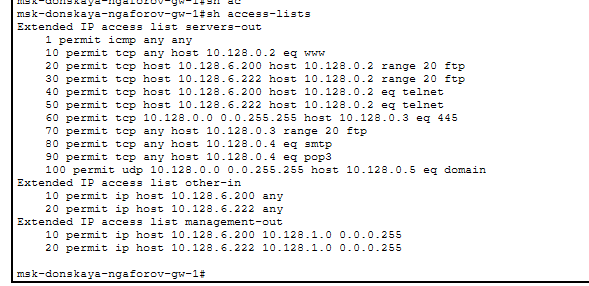

Проверка ACL

## Проверка доступа к web-серверу

- С пользовательского узла открыт адрес: **http://www.donskaya.rudn.edu**
- Страница web-сервера загружается успешно
- Это подтверждает правило: **permit tcp any host 10.128.0.2 eq 80**

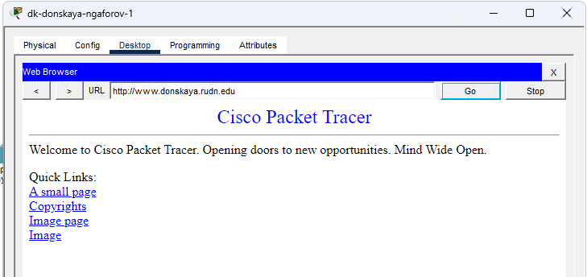

Доступ к web-серверу по HTTP

## Проверка FTP-доступа к web-серверу

- Обычный пользователь:
  - команда **ftp 10.128.0.2**
  - соединение завершается по **Timed out**
- Администратор:
  - выполняет вход по **FTP**
  - успешно проходит аутентификацию

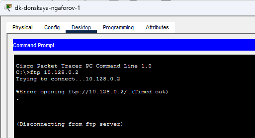

Запрет FTP для обычного пользователя

## FTP-доступ администратора

- С узла **10.128.6.200** выполнено подключение к **10.128.0.2**
- Соединение установлено успешно

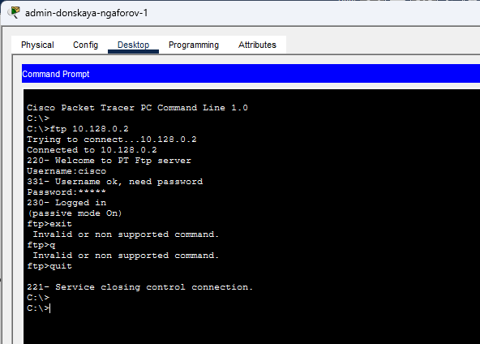

FTP-доступ администратора к web-серверу

## Проверка второго администратора и file-сервера

- Второй администратор **10.128.6.222** также имеет FTP-доступ к web-серверу

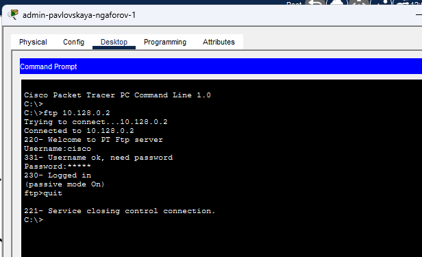

FTP-доступ второго администратора

## Проверка второго администратора и file-сервера

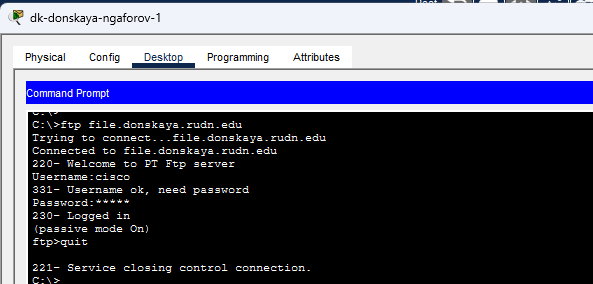

Проверка доступа к file-серверу

## Настройка почтового сервера

- На сервере **mail-ngaforov** включены:
  - **SMTP**
  - **POP3**
- Созданы пользователи:
  - **ngaforov1**
  - **ngaforov2**

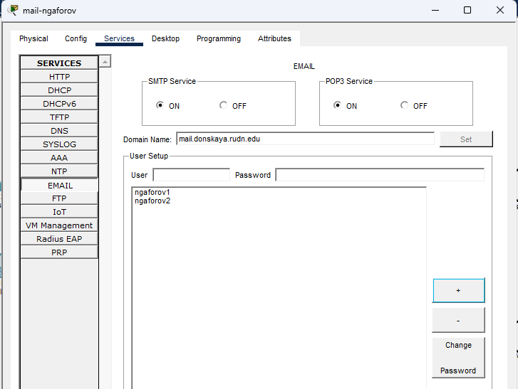

Настройка почтового сервера

## Настройка почтовых клиентов

- Для пользователей настроены почтовые клиенты

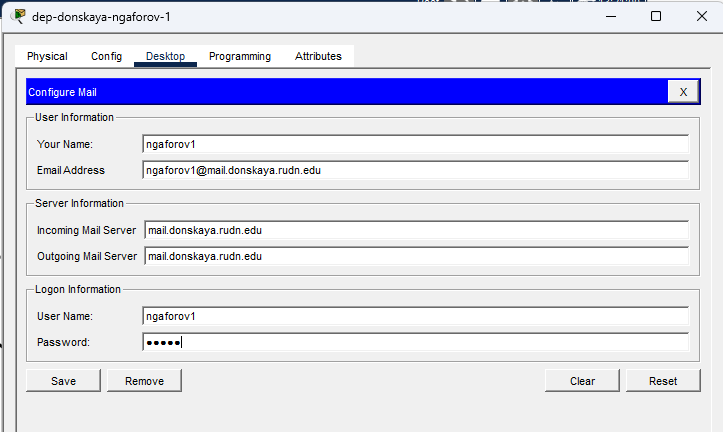

Почтовый клиент пользователя ngaforov1

## Настройка почтовых клиентов

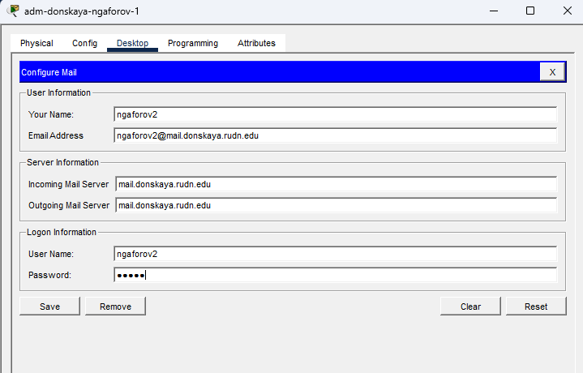

Почтовый клиент пользователя ngaforov2

## Проверка SMTP, POP3 и DNS

- Письмо успешно доставлено между пользователями
- Имя **mail.donskaya.rudn.edu** разрешается через DNS-сервер **10.128.0.5**

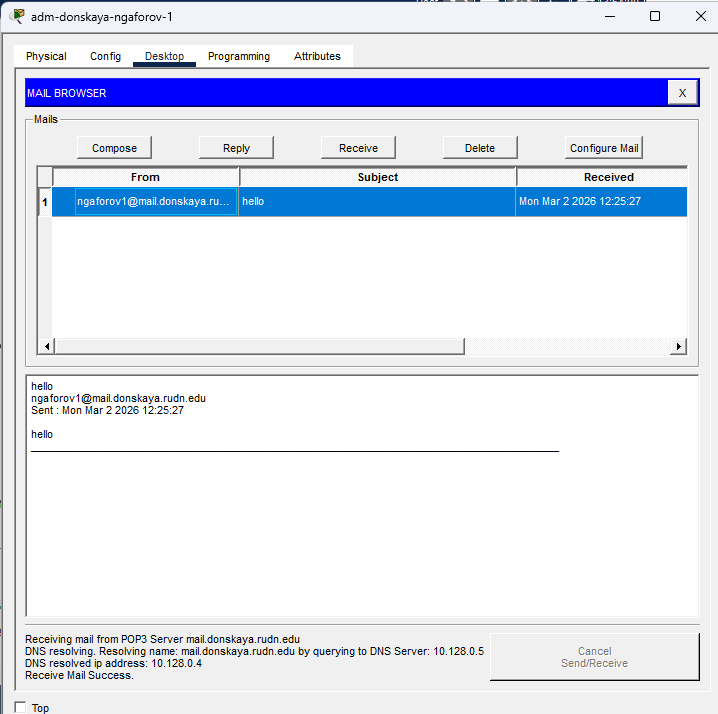

Проверка почты и DNS

## Проверка ICMP-доступности серверов

- Выполнены команды:
  - **ping 10.128.3.31**
  - **ping 10.128.0.2**
- Это подтверждает корректную работу правила, разрешающего **ICMP** в сторону сети серверов

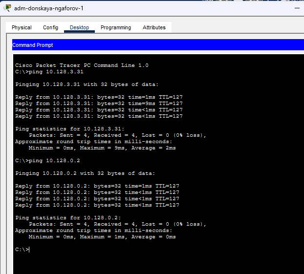

Проверка ICMP-доступа

## Доступ к сети управления

- С узла **10.128.6.200** выполнены SSH-подключения к:
  - **10.128.1.2**
  - **10.128.1.1**
- Значит, ACL **management-out** работает корректно

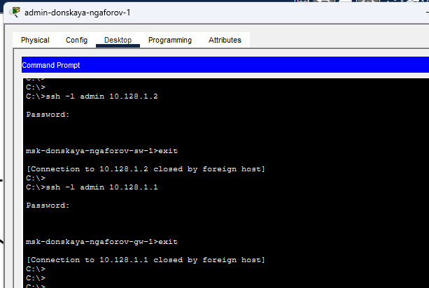

SSH-доступ администратора к сети управления

## Проверка второго административного узла

- Со второго администратора **10.128.6.222** выполнены SSH-подключения к:
  - **10.128.1.3**
  - **10.128.1.4**
- Доступ подтверждён
- Управление сетевым оборудованием доступно только административным узлам

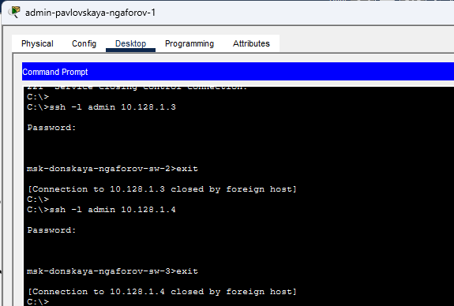

SSH-доступ второго администратора

# Итог

## Вывод

В ходе работы:

- настроены расширенные ACL на маршрутизаторе
- разграничен доступ к **web**, **file**, **mail** и **DNS** серверам
- запрещён лишний трафик из сети **Other**
- разрешён доступ в сеть управления только администраторам
- подтверждена корректная работа правил по **HTTP, FTP, SMTP, POP3, DNS, ICMP, SSH**